# **Tuto Création Package R**

## 4 Exporter le package

Après avoir effectué des vérifications avec `devtools::check()` et confirmé l’absence de warnings ou d’erreurs, l’utilisation de `devtools::build()` est nécessaire pour construire et exporter le package dans un fichier tar.gz. De plus, il existe d’autre option pour le déploiement du package. On peut en effet les déployer sur le CRAN, ou sur Github.

## 5 Utiliser le package

Il existe plusieurs méthodes pour importer un package. Tout d’abord, on peut l’installer à partir d’un fichier tar.gz ou directement depuis le CRAN en utilisant la fonction `install.package('nom_du_package', ...)`. Alternativement, on peut l’installer à partir de GitHub en utilisant la fonction `devtools::install_github("nomdurepos")`. Ces options offrent une flexibilité dans l’installation des packages, permettant à chacun de choisir la méthode qui lui convient le mieux en fonction de ses besoins et de ses préférences.

Pour l’utiliser ensuite, on peut soit l’importer avec `library('nomdupackage')` ou en ne chargeant pas le package en entier, mais en utilisant une fonction spécifique avec `package::fonction()`.

## 6 Maintenir le package

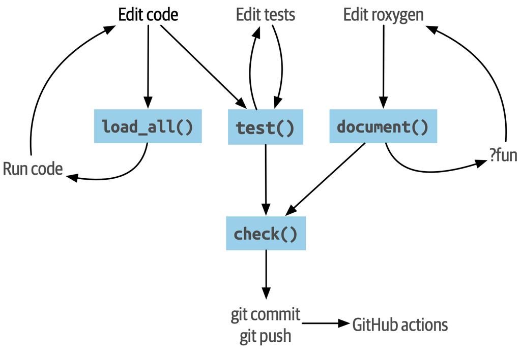

Après avoir ajouté de nouvelles fonctionnalités, il est essentiel de tester le package en utilisant `devtools::load_all()` et `devtools::check()`. Ensuite, on peut ajouter une documentation détaillée avec `document()` pour guider les utilisateurs sur l’utilisation du package. Pour mettre à jour le package, on peut aussi actualiser le dépôt GitHub ou reconstruire le package avec `devtools::build()`. On peut également utiliser `usethis` pour créer des notes de version et effectuer des mises à jour mineures ou majeures. Les possibilités de création, personnalisation, modification, test et maintenance d’un package sur R sont pratiquement infinies. Cet aperçu a résumé les fonctionnalités essentielles pour bien démarrer, mais je vous recommande de consulter la [documentation officielle](https://r-pkgs.org/) pour plus de détails.